# 1 . Arena Automation System

    Note that the Matlab output window likely reported a very high calibration error. This is due to the imperfect automatic tracking of the wand.
14. Now exit the EasyWand window. Type "DLTdv5" in the Matlab window.
15. When asked how many cameras to process, select the correct number. Then select each camera wanding video file when prompted. *Be sure, for consistency and to prevent errors later, to select the appropriate file when asked to "Pick movie file {N}"*. For example, select *wanding__C001H001S0001.avi* when asked for movie file 1, and *wanding__C002H001S0001.avi* when asked for movie file 2.

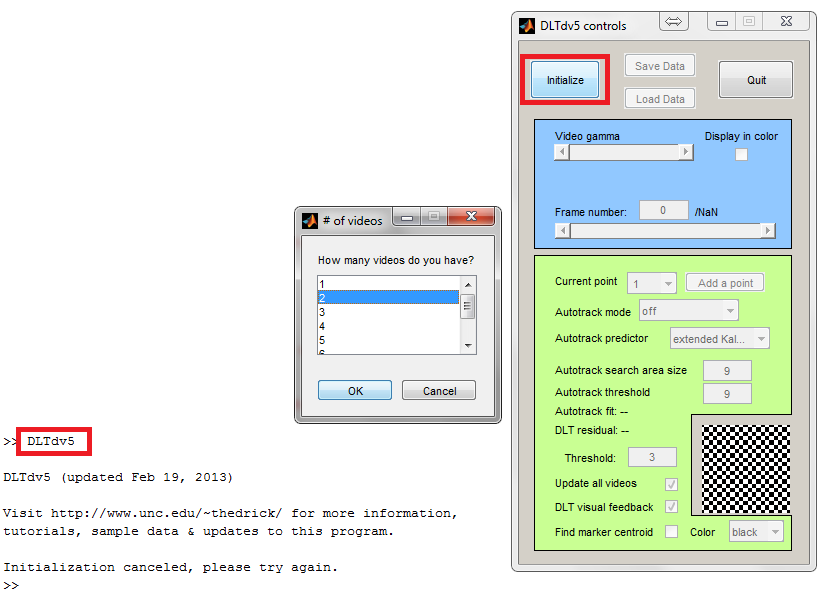

16. When asked if these cameras are calibrated via DLT, choose "yes." Then select the *wanding_dltCoefs.csv* file we just generated using easyWand2b.
17. Now click "Load Data," and select the "*wanding.xypts.csv*" file generated by the automatic wand digitizing software earlier.

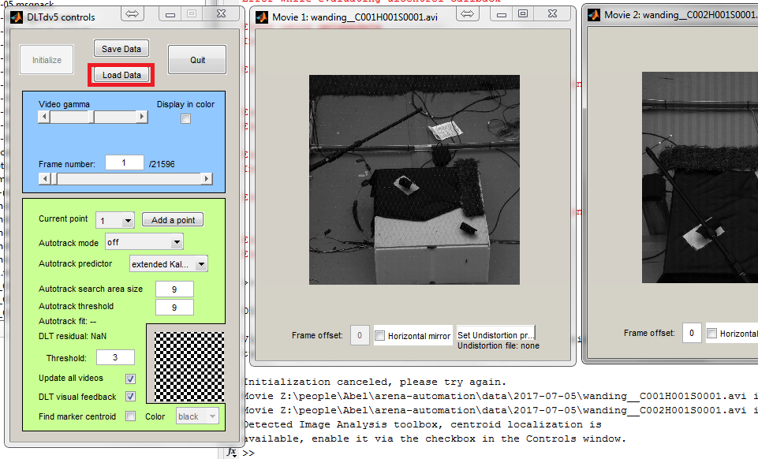

18. Then click anywhere on one of the movie windows, and subsequently press SHIFT-R. You should see the message "Recomputing all 3D coordinates" in the main Matlab console window.

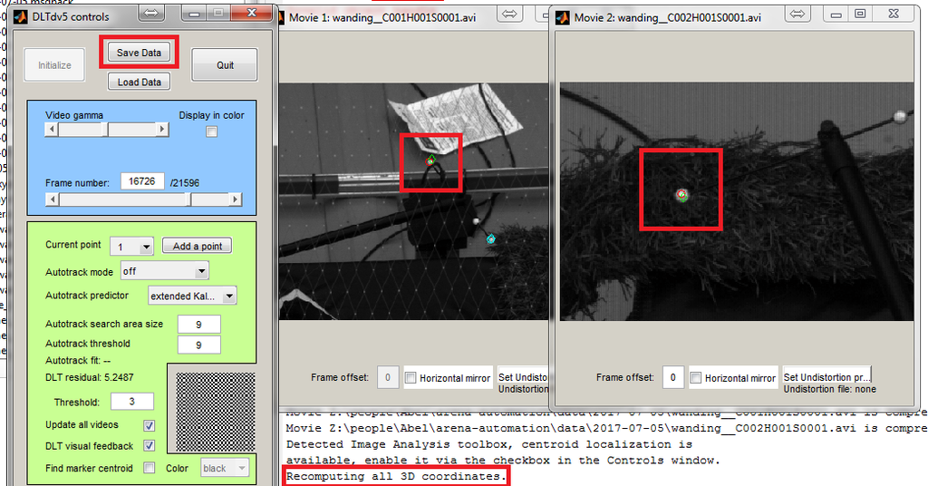

19. Click "Save Data" and select the same folder as the original. In the subsequent "Data File Prefix" window, select the same file prefix as the input file, i.e. the prefix "*wanding.*". This will keep the original 2D data the same, but compute 3D residuals. When asked to overwrite existing data, select "Yes."
20. When asked to create 95% CI's, select "No."
21. Click "Quit" to exit DLTdv5
22. Now run "remove-easywand-outliers.bat". (Or execute the "remove-easywand-outliers.py" manually from the command line.)
23. In the file dialog that appears, select the XY wanding coordinate file we just (re-)saved, "*wanding.xypts.csv*".
24. This will create the file "*wanding.no_outliers.xypts.csv*", which contains the subset of XY(Z) markers with relatively low residuals.
25. Go back to Matlab, and (again) run "easyWand2b". We now repeat the steps we did before: Load the same axis file as before, change the wand span to "0.2". However, for wand points we now select the low-residual subset we just created, "*wanding.no_outliers.xypts.csv*".
26. Again click "Compute calibration." This will again take a while.
27. Again select "No" when asked whether to optimize the axis origin.
28. Notice that the wanding residuals have now drastically reduced:

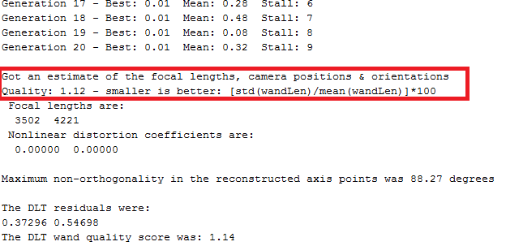

29. Again click "Save results." When asked for a filename, type "wanding". This will again create a "*wanding_dltCoefs.csv*" file. Then close easyWand2b as before.
30. Again, type "DLTdv5" in the Matlab command prompt.
31. In the window that appears, again click "Initialize", and select the videos as before (in the right order).
32. When asked if the cameras are calibrated via DLT, again select "Yes."
33. Select the (now updated) "*wanding_dltCoefs.csv*" file.
34. Again click "Load Data" and select the "*wanding.xypts.csv*" file. (Note: Don't select the "*wanding.no_outliers.xypts.csv*" file!)
35. Again, bring focus to one of the video windows by clicking on e.g. their title bar. Then press SHIFT-R to recompute XYZ coordinates.
36. Press "Save Data," and select the same folder our current files live in.
37. As before, select the file prefix "*wanding.*". Again, when prompted, indicate it is ok to overwrite files.
38. You will be asked if 95% confidence intervals should be computed. Again, this is not necessary for any of our analyses.
39. Quit the DLTdv5 program.
40. Before we continue, ensure that the Cortex .TRC wanding file has been copied to the same data directory we've been working in so far.
41. Now run "calibrate-photron.bat". (Or execute the "calibrate-photron.py" manually from the command line.)
42. When prompted, select the "*wanding.xyzpts.csv*" file we just created.
43. When prompted, select the "*wanding_N.trc*" we just copied to this directory.
44. When this script finishes, it will have produced a "*3dcalibration_dlt_adjustment.pickle*" file. This file contains linear regressions aligning any DLTdv5-generated XYZ coordinates with the Cortex coordinate system.

    In addition, the script will have produced various debugging plots in the "debug/3dcalibration/" subfolder.

[figure not shown]

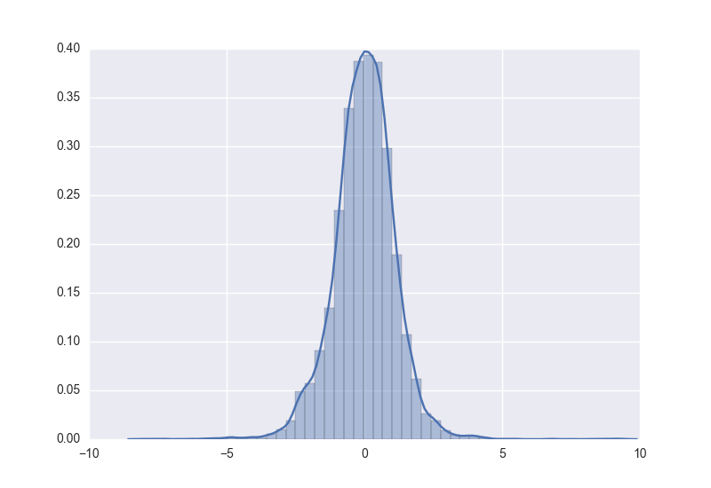

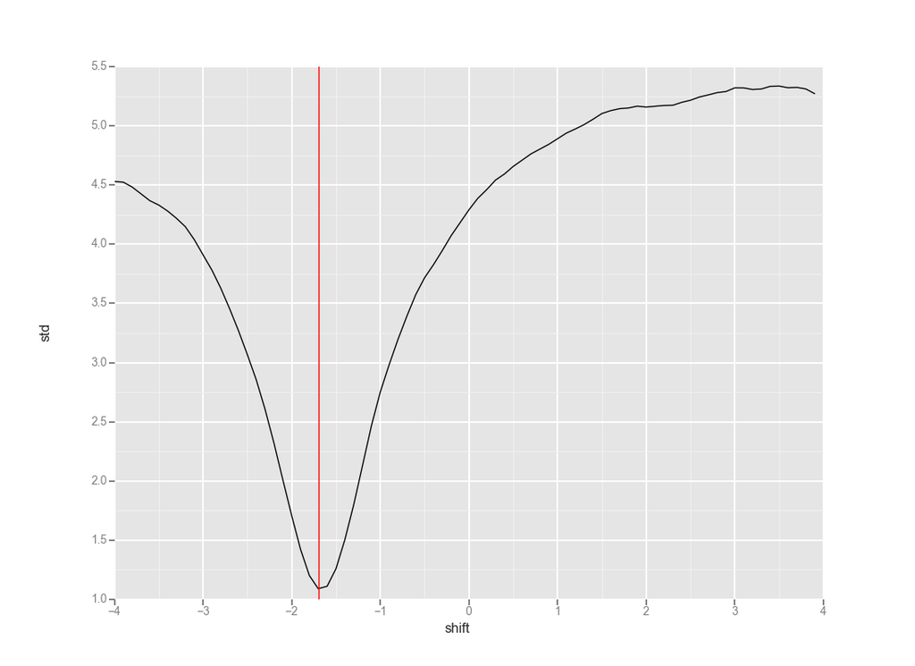

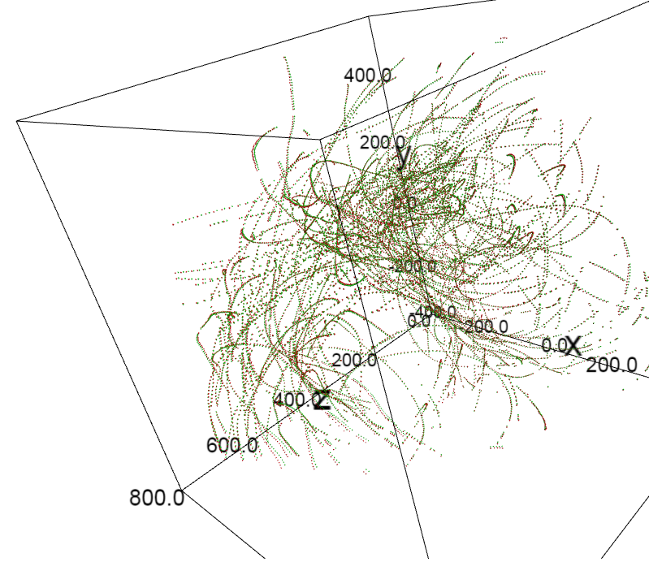

## 1.2 . Technical documentation

### 1.2.1 . About the documentation

The documentation is written in Pandoc-flavored Markdown. A good reference on this flavor of Markdown can be found **[here](http://rmarkdown.rstudio.com/authoring_pandoc_markdown.html)**.

### 1.2.2 . Hardware wiring diagram

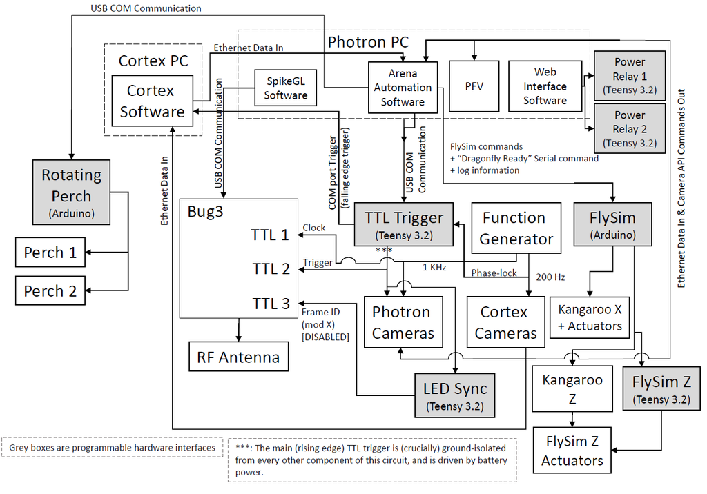

### 1.2.3 . High-level overview

The *Arena Automation System* consists of roughly two components. A real-time pipeline, and an offline post-processing pipeline. The real-time system has three main goals:

#### 1.2.3.1 . The realtime pipeline

- **Goal 1: Save all motion capture data**.

The real-time system receives every single 3D marker point, and saves its XYZ coordinates. The output file contains all these markers (*.msgpack files) is the most important reference dataset, from which all analysis scripts start.

In addition, the real-time system continuously interfaces with the Cortex software, and triggers the recording of virtually all raw mocap data. Because these blocks have to be re-triggered, about .5 seconds of data is lost for every minute of recording. However, because the XYZ marker data (as opposed to the raw XY camera centroids) is streamed independently, no XYZ data is lost.

- **Goal 2: Trigger high-speed cameras and telemetry**

High-speed (Photron) recordings cannot be performed continuously, and therefore need to be triggered. Similarly, the telemetry data recording is currently recorded upon being triggered, and not continuously saved.

The *Arena Automation System* continuously streams motion capture data from the Cortex software in real-time, and tracks the identified Yframes. Upon detection of a takeoff event (currently based on a velocity threshold), the system sends a USB command to the Trigger Signal Generator, which phase-locks the trigger with the motion capture and camera clocks. This trigger signal will save all high-speed and telemetry data, and furthermore causes the LED Trigger Signal to blink, creating an identifiable trigger alignment point in the motion capture data stream.

- **Goal 3: Control real-time systems**

Lastly, the real-time component of the *Arena Automation System* interfaces with various peripheral devices that require real-time feedback and are integral to the experiment.

A primary example of this is the Perch Controller. The *AAS* monitors the orientation of the perches, and sends serial commands to the Perch Controller which then rotates the perches.

In addition, the *AAS* monitors whether a dragonfly is currently on the perch and has reached the desired orientation. If so, it notifies the FlySim Controller that the dragonfly is ready. This functionality, if enabled, can be used to limit trial presentation to only those circumstances when the dragonfly is correctly oriented.

Other real-time monitoring functions can be added easily.

#### 1.2.3.2 . The offline pipeline

The goal of the offline pipeline is to extract all dragonfly activity, especially prey-capture flights, from the mass of data collected by the real-time system.

The offline pipeline consists of many scripts (written in Python) that each extract a particular type of information from the raw recordings. Each of these scripts can be run independently, facilitating easier experimentation with new analyses, and allowing subsets of the analysis to be updated without re-running the whole pipeline.

In most cases, however, the pipeline will be run with a single click. The main script that will start the processing will then run each of the processing sub-steps. All analysis output files will be put in the data directory for that day/recording, with the exception of the summary reports, which are in their own folder.

The offline pipeline takes as its starting point the XYZ marker data files produced by the real-time system. These files have .msgpack extensions.

Unless this step is disabled, the first step in the postprocessing pipeline is to merge all data files recorded on the same day, under the assumption that a given day will only contain a single type of experiment.

### 1.2.4 . Overview of the technology stack

The technology stack was chosen based on the requirements of each Arena Automation subsystem.

#### 1.2.4.1 . The real-time pipeline

The real-time pipeline ("*ArenaAutomation.exe*") is written entirely in **C/C++**. This facilitates rapid processing.

#### 1.2.4.2 . The real-time web interface

The real-time web interface is mostly just an HTML front end for the API that the real-time C/C++ software exposes. The web interface Graphical User Interface (GUI) is written in HTML/Javascript. The web backend in also written in Javascript, and runs on NodeJS.

#### 1.2.4.3 . The post-processing pipeline

All postprocessing scripts --- with some minor exceptions, see below --- are written in **Python 3.5**. Note that Python 2.7 and 3.5 are not compatible, and therefore future additions to the Python software have to be written in Python 3.x as well.

In addition to the Python post-processing pipeline, several debugging scripts can be found in the form of **Jupyter Notebooks**. These notebooks contain Python code. *Jupyter Notebooks are the recommended way of debugging and interacting with the Arena Automation postprocessing pipeline, as they can directly call the utility libraries.*

The exceptions, not written in Python, are:

- The Photron 3D calibration code is written in Matlab.
- Some debugging scripts, which were occasionally used for quickly inspecting output files, were written in R. These scripts are in no way required by the processing pipeline, but have been kept in a few directories in case their basic content proves useful in the future.

### 1.2.5 . Debugging and Running the Python Code

The Integrated Development Environment (IDE) used to develop the post-processing (Python) pipeline is the PyCharm IDE (see below). This IDE is the best way to familiarize yourself with the different Python postprocessing scripts, as well as run, debug and edit individual scripts.

[figure not shown]

### 1.2.6 . Hardware Subsystems

This section documents the capabilities of each hardware interface. In the case of Arduino-compatible interfaces, it details the available commands that are available using the Serial interface.

#### 1.2.6.1 . Opening a serial interface

1. Open the "Arduino IDE"
2. Open serial (/COM) port 6. **Note:** The COM port might be different than 6. We will see soon how to verify whether we selected the right port.

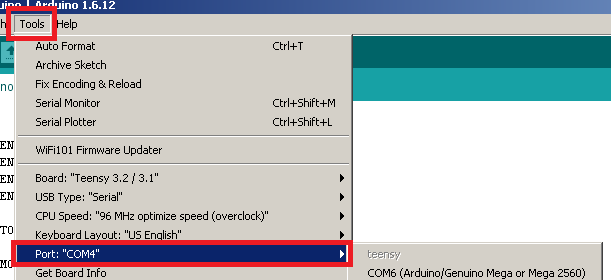

   Newline settings should be set to "Newline," and the baud rate to 9600 for the devices below, unless otherwise noted.
3. Open the Serial Monitor (CTRL-SHIFT-M)

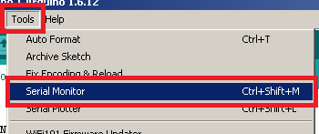

4. In the serial monitor window that appears, type "h" followed by ENTER.
5. The output will indicate what device has been connected to.

#### 1.2.6.2 . Arduino interfaces

Each Arduino interface is programmed according to a similar framework, which facilitates modularizing available commands, and extending them later. The available commands are listed below.

##### 1.2.6.2.1 . FlySim Controller

1. Connect to the FlySim controller as outlined in the section "Opening a serial interface." (Current COM Port: 6)
2. The following commands are available:
   2. **h**: Send a string identifying this controller
   3. **z**: Send the FlySim line to a particular height (calibrated to mm). The height should be correct to within a few millimeters. If more accuracy is required, acceptable error limits should be changed in the code, and calibration values should be tuned.

##### 1.2.6.2.2 . Rotating perch Controller

1. Connect to the Rotating Perch controller as outlined in the section "Opening a serial interface." (Current COM Port: ?)

##### 1.2.6.2.3 . TTL Trigger Controller

1. Connect to the TTL Trigger controller as outlined in the section "Opening a serial interface." (Current COM Port: 4)

##### 1.2.6.2.4 . Power Controller (1 & 2)

1. Connect to the Power controller as outlined in the section "Opening a serial interface." (Current COM Port: ?)

##### 1.2.6.2.5 . LED Sync Controller

1. Connect to the LED Sync controller as outlined in the section "Opening a serial interface." (Current COM Port: ?)

##### 1.2.6.2.6 . FlySim Z Controller

1. Connect to the FlySim Z controller as outlined in the section "Opening a serial interface." (Current COM Port: ?)

## 1.3 . Future directions

1. **Facilitate manually processing selective frame ranges in Cortex.**: Given that Cortex data files are automatically saved, it is possible to process any events that occur directly in Cortex. There are two approaches:
   - For every takeoff event, include the Cortex filename (*".cap"*) and frame range of the event. The user can then manually open the relevant file and navigate to the correct framerange.
   - For every trajectory, create a new Cortex file with just the relevant framerange.